# [Metrololo #1] Les mamies de Paris

Mathieu

26/05/2017

A l’heure de la “smart city” augmentée par les outils numériques de ses citoyens, de la métropole rayonnante par ses activités universitaires et son économie mondialisée , la “ville inclusive” reste-t-elle aussi accueillante pour les seniors qui y ont fait leur vie. Laisse-t-elle encore une place aux mamies qui déambulent dans les rues et cassent le rythme frénétique de l’urbanité ?

Pour ce premier épisode d’une petite série sur les disparités socio-démographiques au sein l’agglomération parisienne, honneur à nos ainées. Pour l’occasion on regroupe sous le terme affectif de “mamies” la population féminine âgée de plus de 65 ans, en espérant que personne n’en soit choquée. Elles sont 6,6 millions en France (selon les chiffres du dernier recensement de l’Insee en 2013) et représentent 10,4% de la population contre 8,9% en 1990, vieillissement global de la population oblige. Voici d’abord une carte de leur localisation dans le pays :

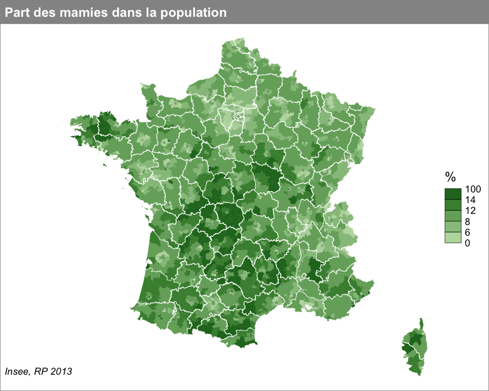

La région Parisienne est donc la moins pourvue en mamies alors que les zones rurales du centre et du Sud-Ouest, la Basse-Normandie et le Centre-Bretagne accueille en proportion davantage de mamies. Sous l’effet de l’héliotropisme mais surtout de l’haliotropisme, elles sont dorénavant plus présentes sur les littoraux atlantique et méditerranéen.

## L’analyse infra-urbaine par station

Pour comprendre les phénomènes socio-démographiques qui se jouent à l’échelle du quartier, on va se baser sur les zones entourant les stations de transports en commun (métro, tram, RER et transilien) de la région Ile de France. La station (ou la gare) fait en effet souvent office de lieu de centralité dans la vie quotidienne des habitants et c’est principalement à elle qu’on fait référence pour évoquer son quartier. Toute la méthodologie pour arriver à ses résultats est détaillée dans la méthodo et sur la page github du projet metrololo.

Voici donc la carte des stations selon la part des mamies dans la population d’après les données 2013. Intra-muros, plusieurs zones se détachent : le sud du 16ème arrondissement, le 6ème ou l’Est du 12ème. Dans cet arrondissement on trouve de très fortes disparités avec 14% de mamies près de la station Bel-Air mais moins de 5% à la station Cour Saint-Emilion, un quartier qui a été totalement rénové dans les années 1990 et où sont venus s’installer de jeunes couples et des familles. Un clic sur votre station permet d’afficher ses stats.

[interactive chart not shown]

Globalement la rive droite est moins peuplée de mamies, et cela ne vas pas en s’arrangeant : en visualisant l’évolution du taux de mamies entre 1990 et 2013 (menu à droite), on voit que cette part a fortement diminué dans un grand quart Nord-Ouest de la capitale. Un dézoom pour s’éloigner de Paris fait apparaître une “mamification” importante de la banlieue Ouest.

Rentrons un peu dans le détail avec le graphique suivant. La lecture est un peu tordue, accrochez-vous. Chaque station est symbolisée par un point dont la position est fonction de son taux de mamies 2013 en ordonnée (plus c’est haut, plus il y en a) et sa position en abscisse selon son arrondissement. Un trait vertical permet aussi de voir l’évolution de son taux depuis 1990, le code couleur bleu/rouge montrant également la même information.

[interactive chart not shown]

Même si son taux a légèrement diminué depuis 1990, la station Chardon-Lagache remporte la palme de la station où l’on trouve le plus de mamies (toujours en proportion de sa population, bien sûr), suivie de près par la Porte d’Auteuil. Tout en bas la station Avenue de France, complétement réhabitée en marge des chantiers de la BNF, est elle atteinte d’un jeunisme paroxistique avec moins de 3% de mamies. Si vous y en croisez une, félicitez-la c’est une curiosité locale. Les situations des stations du 13ème sont d’ailleurs très disparates puisque la station Nationale compte 13,5% de mamies et ce taux a fortement progressé depuis 1990.

Les 8ème, 9ème et 10ème arrondissements présentent des stations très bleues, cela signifie que les mamies ont fuit depuis 20 ans : la cohabitation inter-générationnelle serait-elle mise à mal ?

Passons à la banlieue avec les stations des 3 départements de petite couronne :

[interactive chart not shown]

Sans grande surprise on trouve les stations de mamies davantage dans les Hauts-de-Seine (Bellevue à Meudon en tête) et c’est un phénomène qui a pris beaucoup d’ampleur depuis les années 1990. Au contraire des quartiers très récents comme Front Populaire et La Plaine-Stade de France battent des records avec moins de 2% de mamies.

Enfin les 4 départements de grande couronne de la région Ile-de-France :

[interactive chart not shown]

Le phénomène qui se dégage visuellement est d’abord l’augmentation quasiment généralisée de la part de mamies avec des traits verticaux en rouge. Les mamies se sentiraient-elles plus en sécurité loin de la capitale ? Provins, cité médiévale endormie, est à ce titre un exemple typique.

Prochain épisode : on regardera probablement si les poussettes font regner la loi dans votre quartier.

## methodologie

Les scripts sont dipos [ici](https://github.com/mtmx/metrololo) :

- Pour obtenir la carte par canton, le package COGugaison est bien pratique pour vérifier le millésime du Code Officiel Géographique (COG) de ses données, les convertir dans un autre ou changer de maille géographique. Le contour communal des communes de janvier 2017, pour créer tous les contours supra-communaux, est fourni gracieusement par l’IGN [IGN](http://professionnels.ign.fr/adminexpress). Pour simplifier les contours et alléger les géometries, rien de mieux que [rmapshaper](https://cran.r-project.org/web/packages/rmapshaper/)
- Les stations de métro, tram et RER ont été récupérées via l’[API Open Street Map](https://www.data.gouv.fr/fr/datasets/stations-et-gares-de-metro-rer-et-tramway-de-la-region-ile-de-france/) à partir des infos RATP et celles du réseau Transilien via la SNCF et OSM. Le référentiel exhaustif a ensuite été unifié et dédoublonné, les coordonnées des stations manquantes ont finalement été scrappées depuis leurs pages wikipedia.
- Le territoire d’Ile de France est ensuite découpé en autant de quartiers que de stations, ils correspondent chacun à la zone la plus proche de chaque station selon le principe du [diagramme de voronoi](https://fr.wikipedia.org/wiki/Diagramme_de_Vorono%C3%AF). Quand les stations sont trop éloignées les unes des autres, on limite les quartiers à un rayon maximal de 700 mètres (c’est le cas en banlieue mais rarement à Paris intra-muros).
- Les contours de ces “quartiers/stations” sont ensuite croisés avec les contours des IRIS, et les données à l’IRIS sont ventilées par quartier au pro-rata de leur superficie incluse. Ce serait plus propre de ventiler les données au prorata de la population localisée précisément grâce au package spReapportion mais aucune donnée n’est satisfaisante pour l’instant : les adresses de la BAN ne contiennent pas de proxy de la population et les parcelles cadastrales mises à disposition par l’IAU sur [Paris](http://cassini-apur.opendata.arcgis.com/datasets/002f14c0cf28435296a341d9921adf99_0) et sa [petite couronne](http://opendata.apur.org/datasets/emprise-batie-petite-couronne) ne nous permettraient que d’approximer la surface batie ce qui n’irait pas sans poser un souci pour les immeubles de grande hauteur.
- Les cartes sont réalisées grâce aux packages [cartography](https://cran.r-project.org/web/packages/cartography/) et [leaflet](https://cran.r-project.org/web/packages/leaflet/), les graphiques grâce à [ggplot](https://cran.r-project.org/web/packages/ggplot2/) et son sidekick interactif [ggiraph](https://cran.r-project.org/web/packages/ggiraph/)